# Guia Rápido de DataViz com ggplot2: Escolha de Gráficos e Códigos em R

Henrique Dayrell, Joaquim Almeida

Novembro de 2025

## Introdução: Essência do DataViz

A visualização de dados (*DataViz*) é a arte de transformar informações complexas em representações visuais claras, que ajudam a revelar padrões, tendências e comparações de forma rápida e intuitiva.

Antes de escolher um gráfico, é fundamental responder: **qual mensagem você deseja comunicar?**

Cada tipo de visualização enfatiza um aspecto diferente dos dados. Neste guia, organizamos as opções mais comuns em quatro categorias principais:

1. **Relação**
2. **Distribuição**
3. **Comparação**
4. **Composição**

## Preparando as configurações do arquivo

Primeiro, vamos definir algumas pequenas configurações

```r
# Carrega o pacote principal para os exemplos
require(ggplot2)
library(tidyverse)

# Criar dados falsos para exemplos
set.seed(123)
dados <- data.frame(
    categoria = factor(sample(LETTERS[1:4], 50, replace = TRUE)),
    valor_y = rnorm(50, 50, 10),
    valor_x = rnorm(50, 100, 15),
    tempo = 1:50
)
```

Com isso, podemos começar a trabalhar :)

## 1ª Categoria — Relação

Visualizações dessa categoria mostram como duas variáveis se comportam em conjunto, ajudando a identificar **tendências, associações ou correlações.**

### Gráfico de Dispersão (Scatter Plot)

O *Scatter Plot* é ideal quando o objetivo é analisar a relação entre duas variáveis numéricas. Ele permite observar padrões, identificar correlações e localizar possíveis outliers. É uma das ferramentas mais úteis na análise exploratória.

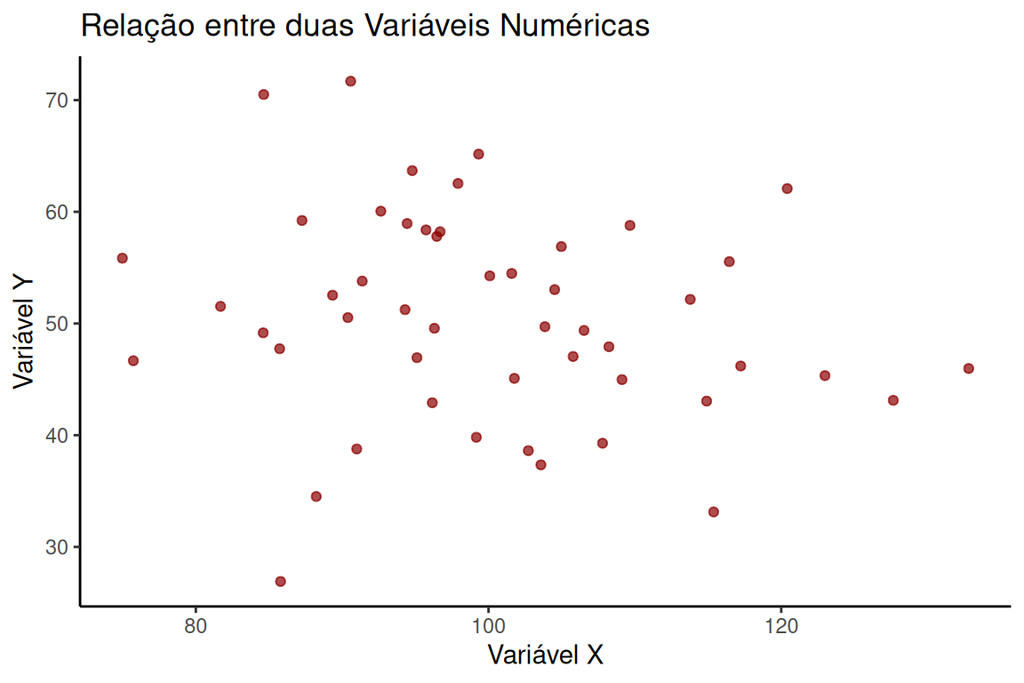

```r
# Exemplo: Existe relação entre 'valor_x' e 'valor_y'?
ggplot(dados, aes(x = valor_x, y = valor_y)) +
  geom_point(color = "darkred", alpha = 0.7) +
  labs(title = "Relação entre duas Variáveis Numéricas",
       x = "Variável X",
       y = "Variável Y") +
    theme_classic()
```

## 2ª Categoria — Distribuição

Esses gráficos mostram como os valores de uma única variável se distribuem, permitindo identificar **forma, dispersão, centralidade e valores extremos.**

### Histograma

O histograma é uma visualização essencial para entender o comportamento geral de uma variável numérica. Ele revela se a distribuição é simétrica, assimétrica, larga, estreita ou se possui mais de um pico. Excelente para análises exploratórias iniciais.

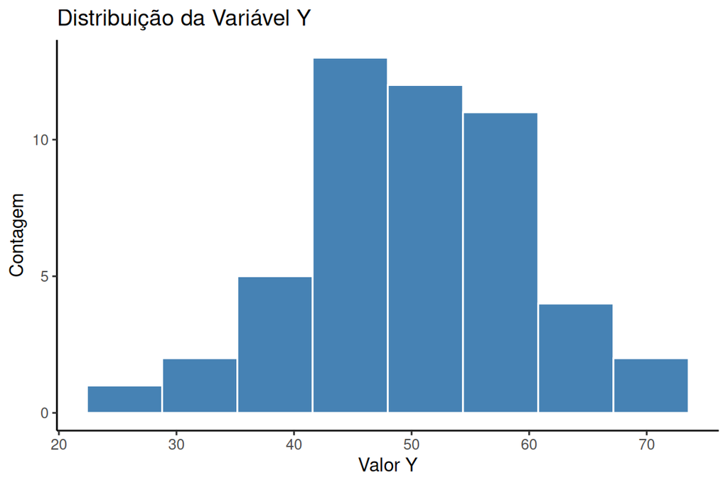

```r
# Exemplo: Como se distribuem os valores da 'valor_y'?
ggplot(dados, aes(x = valor_y)) +
  geom_histogram(bins = 8, fill = "steelblue", color = "white") +
  labs(title = "Distribuição da Variável Y",
       x = "Valor Y",
       y = "Contagem") +
    theme_classic()
```

## 3ª Categoria — Comparação

Visualizações dessa categoria comparam **valores entre diferentes grupos**, categorias ou séries temporais. São amplamente utilizadas em relatórios e dashboards.

### Gráfico de Barras

O **Gráfico de Barras** é a forma mais robusta e simples de comparar valores ou contagens de diferentes categorias.

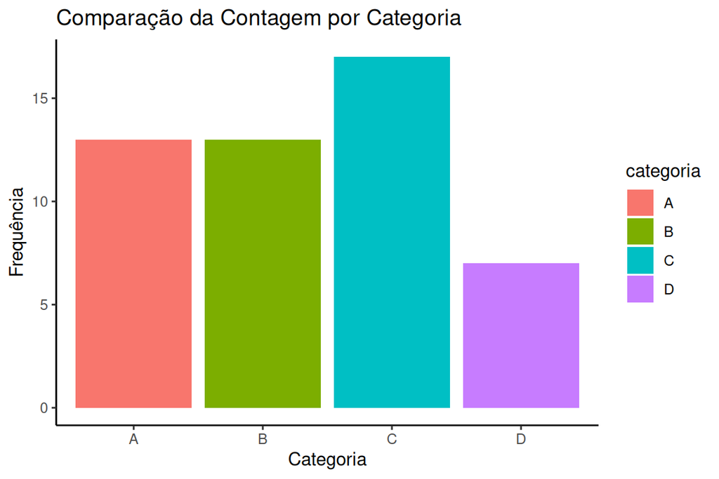

```r
# Exemplo: Comparando a contagem de observações por 'categoria'
ggplot(dados, aes(x = categoria, fill = categoria)) +
  geom_bar() +
  labs(title = "Comparação da Contagem por Categoria",
       x = "Categoria",
       y = "Frequência") +
  theme(legend.position = "none")  +
    theme_classic()
```

### Gráfico de Pirulito

Um substituto para o gráfico de barras simples pode ser o *Lollipop Plot*. Esse tipo de visualização é especialmente útil quando se deseja comparar mais de uma variável quantitativa entre si, mantendo o foco nas diferenças de forma mais limpa do que um gráfico de barras tradicional.

Além disso, o Lollipop Plot **reduz o “peso visual”** das barras e facilita a leitura quando há muitas categorias, evitando poluição visual. Ele também permite destacar valores específicos com mais elegância, tornando-o uma boa escolha para apresentações, relatórios ou dashboards que exigem clareza e organização.

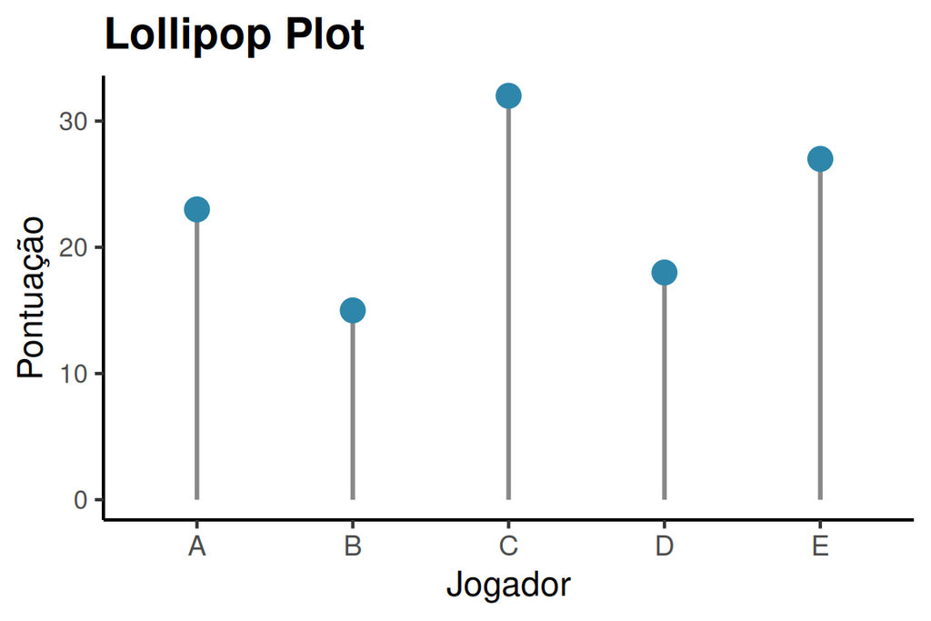

```r
df <- data.frame(
  Categoria = c("A", "B", "C", "D", "E"),
  Valor = c(23, 15, 32, 18, 27)
)
ggplot(df, aes(x = Categoria, y = Valor)) +
  geom_segment(aes(x = Categoria, xend = Categoria, y = 0, yend = Valor),
               color = "#888888", linewidth = 1) +
  geom_point(color = "#2E86AB", size = 5) +
  labs(
    title = "Lollipop Plot",
    x = "Jogador",
    y = "Pontuação"
  ) +
  theme_classic(base_size = 16) +
  theme(
    plot.title = element_text(face = "bold", size = 20),
    plot.subtitle = element_text(size = 14, color = "#555"),
    axis.text.x = element_text(size = 13),
    axis.text.y = element_text(size = 12)
  )
```

## 4ª Composição

Mostra como as **partes contribuem para o todo**, geralmente enfatizando proporções ou participações relativas entre subgrupos.

### Gráfico de Waffle

Outra alternativa interessante é o *Waffle Plot*, uma visualização formada por uma grade de pequenos formatos, em que cada unidade representa uma **fração do total**. Esse tipo de gráfico é ideal para variáveis qualitativas, especialmente quando o objetivo é mostrar proporções ou participações relativas de cada categoria dentro de um todo.

O *Waffle Plot* costuma ser uma escolha mais eficaz que o gráfico de pizza/setores porque permite perceber **proporções com maior precisão**, já que os valores são representados por unidades discretas e facilmente comparáveis. Além disso, ele evita problemas comuns dos detores, como dificuldade em comparar ângulos ou identificar fatias muito pequenas, e oferece uma leitura visual mais intuitiva.

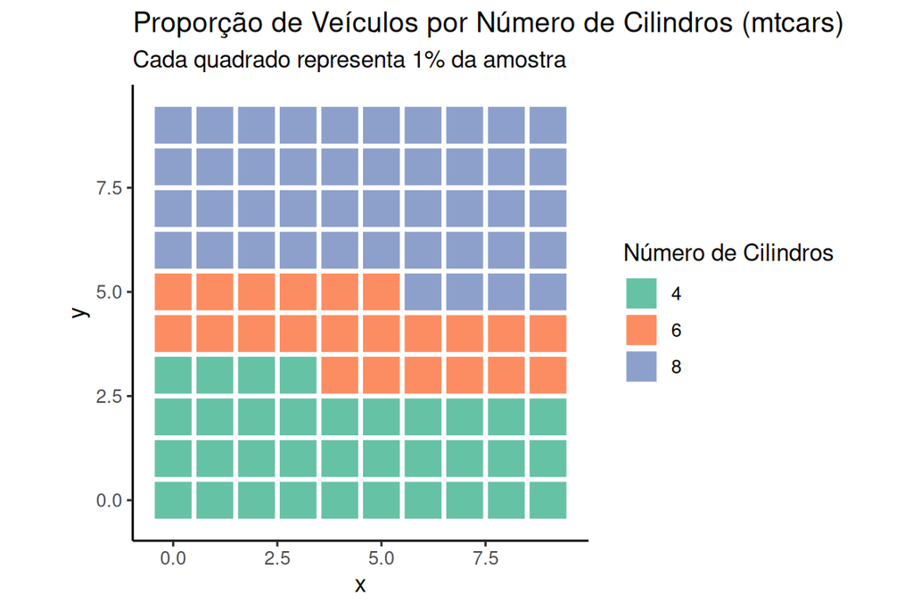

```r
# 1. Contagem por categoria
dados <- mtcars %>%
  count(cyl) %>%
  mutate(prop = n / sum(n))

# 2. Criar 100 quadrados
waffle <- dados %>%
  mutate(quadrados = round(prop * 100)) %>%
  uncount(quadrados) %>%
  mutate(index = row_number(),
         x = (index - 1) %% 10,
         y = (index - 1) %/% 10)

# 3. Waffle plot
ggplot(waffle, aes(x = x, y = y, fill = factor(cyl))) +
  geom_tile(color = "white", size = 0.6, width = 0.95, height = 0.95) +
  scale_fill_brewer(
    palette = "Set2",
    name = "Número de Cilindros"
  ) +
  coord_equal() +
  labs(
    title = "Proporção de Veículos por Número de Cilindros (mtcars)",
    subtitle = "Cada quadrado representa 1% da amostra"
  ) +
  theme_void(base_size = 20) +
  theme(
    plot.title = element_text(face = "bold", size = 26, hjust = 0.5),
    plot.subtitle = element_text(size = 16, hjust = 0.5, color = "#555555"),
    legend.position = "bottom",
    legend.title = element_text(size = 16),
    legend.text = element_text(size = 14),
    plot.margin = margin(20, 20, 20, 20)
  ) +
  theme_classic()
```

## Tabela Resumo: Como Escolher um Gráfico

| Objetivo de Análise | Melhor Tipo de Gráfico | Por que Usar |
| --- | --- | --- |
| Comparar categorias | Barras / Lollipop | Leitura direta, destaca diferenças entre grupos |
| Mostrar proporções do todo | Waffle | Proporções claras, unidades discretas facilitam comparação |
| Ver relação entre duas variáveis | Dispersão (Scatter Plot) | Evidencia correlações, padrões e outliers |
| Entender a distribuição de uma variável | Histograma | Mostra forma, centro, variabilidade e assimetrias |
| Comparar muitos valores com menos poluição visual | Lollipop | Reduz peso visual e mantém precisão |
| Substituir gráfico de pizza com mais clareza | Waffle | Evita dificuldade com ângulos e fatias pequenas |